# Bangalore morning rain between 8-10am

2026-07-03

## Question

When does it rain in Bangalore in the morning 8-10 am? do we ever require an umbrella then?

## Analysis contract

- **Unit of analysis:** one observed hourly record.
- **Main denominator:** all observed hours in 1981-2025, or all 8-10am hours when looking at the commute window.
- **Main metric:** share of hours with rain > 0.1 mm.
- **Sensitivity check:** rain > 0 mm gives the same broad timing.
- **Comparison:** month-by-month timing, with a focus on the 8-10am window.
- **Umbrella proxy:** any rain in the 8-10am window on a given day.

## Data prep

```r
rain_hourly <- blrRain %>%
  transmute(
    DT = as_datetime(DT),
    date = as_date(DT),
    year = year(DT),
    month = month(DT),
    hour = hour(DT),
    rain_mm = as.numeric(Rain)
  ) %>%
  filter(!is.na(rain_mm), year >= 1981, year <= 2025)

rain_summary <- rain_hourly %>%
  summarise(
    first_dt = min(DT),
    last_dt = max(DT),
    rows = n(),
    days = n_distinct(date),
    years = n_distinct(year)
  )

rain_summary
```

```
##              first_dt             last_dt   rows  days years
## 1 1981-01-01 05:30:00 2025-12-31 23:30:00 394231 16436    45
```

## What the archive says

The 8-10am window is *not* Bangalore’s wettest time of day. Rain in that window is mostly a monsoon and post-monsoon story: it picks up sharply from June, peaks in July-August, stays fairly active into October-November, and is rare in the driest months.

Within the morning itself, 10am is the rainiest of the three hours. Across the full 1981-2025 archive, the share of rainy hours is about 0.9% at 8am, 1.5% at 9am, and 2.5% at 10am in January; it jumps to about 19.5%, 21.9%, and 31.6% in July.

```r
morning_hours <- rain_hourly %>%
  filter(hour %in% 8:10) %>%
  summarise(
    rainy_share = mean(rain_mm > 0.1),
    mean_mm = mean(rain_mm),
    median_mm = median(rain_mm),
    p90_mm = as.numeric(quantile(rain_mm, 0.9)),
    .by = c(month, hour)
  ) %>%
  mutate(
    month_name = month.abb[month],
    rainy_share = round(rainy_share, 3),
    mean_mm = round(mean_mm, 3),
    median_mm = round(median_mm, 3),
    p90_mm = round(p90_mm, 3)
  ) %>%
  arrange(month, hour)

morning_hours
```

```
##    month hour rainy_share mean_mm median_mm p90_mm month_name
## 1      1    8       0.009   0.004      0.00   0.00        Jan
## 2      1    9       0.015   0.005      0.00   0.00        Jan
## 3      1   10       0.025   0.008      0.00   0.01        Jan
## 4      2    8       0.007   0.004      0.00   0.00        Feb
## 5      2    9       0.015   0.005      0.00   0.00        Feb
## 6      2   10       0.026   0.008      0.00   0.01        Feb
## 7      3    8       0.005   0.005      0.00   0.00        Mar
## 8      3    9       0.010   0.006      0.00   0.00        Mar
## 9      3   10       0.026   0.013      0.00   0.02        Mar
## 10     4    8       0.005   0.005      0.00   0.00        Apr
## 11     4    9       0.010   0.006      0.00   0.01        Apr
## 12     4   10       0.020   0.011      0.00   0.03        Apr
## 13     5    8       0.028   0.017      0.00   0.01        May
## 14     5    9       0.037   0.022      0.00   0.03        May
```

[output cut: 22 more lines]

```r
morning_window <- rain_hourly %>%
  filter(hour %in% 8:10) %>%
  summarise(
    window_mm = sum(rain_mm),
    rainy_any = any(rain_mm > 0.1),
    rainy_hours = sum(rain_mm > 0.1),
    .by = c(date, year, month)
  )

window_by_month <- morning_window %>%
  summarise(
    share = mean(rainy_any),
    mean_mm = mean(window_mm),
    p90_mm = as.numeric(quantile(window_mm, 0.9)),
    .by = month
  ) %>%
  mutate(
    month_name = month.abb[month],
    share = round(share, 3),
    mean_mm = round(mean_mm, 3),
    p90_mm = round(p90_mm, 3)
  ) %>%
  arrange(month)

window_by_month
```

```
##    month share mean_mm p90_mm month_name
## 1      1 0.031   0.017  0.020        Jan
## 2      2 0.030   0.017  0.013        Feb
## 3      3 0.029   0.023  0.030        Mar
## 4      4 0.024   0.022  0.050        Apr
## 5      5 0.068   0.071  0.120        May
## 6      6 0.255   0.224  0.404        Jun
## 7      7 0.386   0.354  0.689        Jul
## 8      8 0.338   0.301  0.490        Aug
## 9      9 0.239   0.162  0.330        Sep
## 10    10 0.286   0.207  0.370        Oct
## 11    11 0.228   0.179  0.390        Nov
## 12    12 0.104   0.111  0.200        Dec
```

A useful commute-window read is: a day gets at least one rainy 8-10am hour about **17%** of the time overall, but that rises to **25-39%** in June-August and stays elevated into October-November.

```r
seasonal_window <- morning_window %>%
  mutate(season = case_when(
    month %in% c(12, 1, 2) ~ "DJF",
    month %in% 3:5 ~ "MAM",
    month %in% 6:9 ~ "JJA",
    TRUE ~ "OND"
  )) %>%
  summarise(
    share = mean(rainy_any),
    mean_mm = mean(window_mm),
    .by = season
  ) %>%
  mutate(
    share = round(share, 3),
    mean_mm = round(mean_mm, 3)
  ) %>%
  arrange(match(season, c("DJF", "MAM", "JJA", "OND")))

seasonal_window
```

```
##   season share mean_mm
## 1    DJF 0.056   0.049
## 2    MAM 0.040   0.039
## 3    JJA 0.305   0.261
## 4    OND 0.257   0.193
```

## Chart 1: where 8-10am fits in the daily rain clock

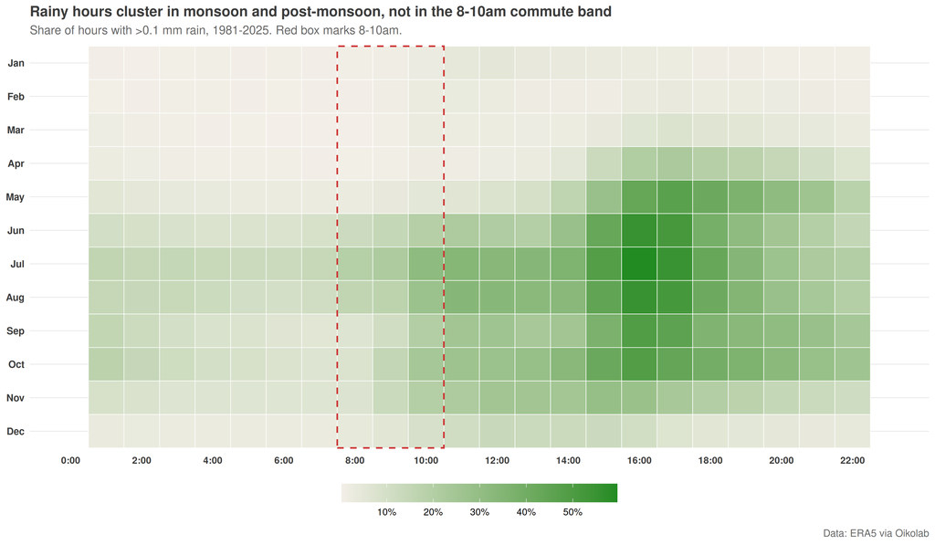

```r
heatmap_data <- rain_hourly %>%
  summarise(
    rainy_share = mean(rain_mm > 0.1),
    .by = c(month, hour)
  ) %>%
  mutate(month_name = factor(month.abb[month], levels = rev(month.abb)))

p_heat <- ggplot(heatmap_data, aes(x = hour, y = month_name, fill = rainy_share)) +
  geom_tile(color = "white", linewidth = 0.25) +
  annotate(
    "rect",
    xmin = 7.5,
    xmax = 10.5,
    ymin = 0.5,
    ymax = 12.5,
    fill = NA,
    color = "#CD3333",
    linewidth = 0.7,
    linetype = "dashed"
  ) +
  scale_x_continuous(breaks = seq(0, 23, 2), labels = paste0(seq(0, 23, 2), ":00"), limits = c(0, 23)) +
  scale_fill_gradient(low = "#f3efe8", high = "#228B22", labels = fmt_pct) +
  labs(
    title = "Rainy hours cluster in monsoon and post-monsoon, not in the 8-10am commute band",
    subtitle = "Share of hours with >0.1 mm rain, 1981-2025. Red box marks 8-10am.",
    caption = "Data: ERA5 via Oikolab"
  ) +
  question_theme() +
  theme(
    axis.text.y = element_text(size = 9),
    legend.position = "bottom",
    legend.key.width = unit(1.8, "cm")
  )

p_heat
```

```r
chart_heatmap_path <- file.path(chart_dir, "bangalore_morning_rain_heatmap.png")
ggsave(chart_heatmap_path, p_heat, width = 12, height = 7, dpi = 180, bg = "white")
```

## Chart 2: how often the 8-10am window needs an umbrella

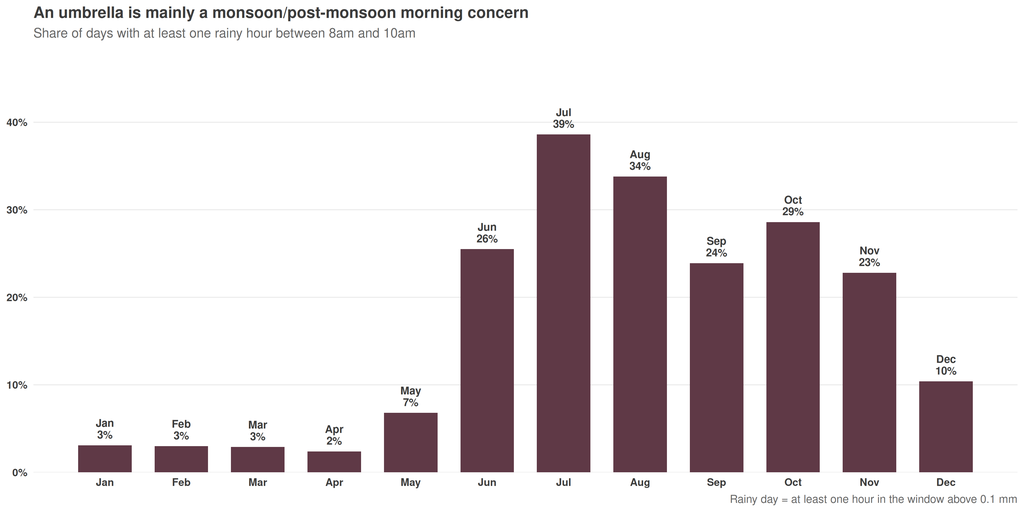

```r
p_window <- ggplot(window_by_month, aes(x = month, y = share)) +
  geom_col(fill = "#5f3946", width = 0.7) +
  geom_text(
    aes(label = paste0(month_name, "\n", round(share * 100), "%")),
    vjust = -0.35,
    size = 3.2,
    fontface = "bold",
    color = "#3C3C3C",
    lineheight = 0.9
  ) +
  scale_x_continuous(breaks = 1:12, labels = month.abb) +
  scale_y_continuous(labels = fmt_pct, limits = c(0, 0.45), expand = expansion(mult = c(0, 0.08))) +
  labs(
    title = "An umbrella is mainly a monsoon/post-monsoon morning concern",
    subtitle = "Share of days with at least one rainy hour between 8am and 10am",
    caption = "Rainy day = at least one hour in the window above 0.1 mm"
  ) +
  question_theme()

p_window
```

```r
chart_window_path <- file.path(chart_dir, "bangalore_morning_rain_window_share.png")
ggsave(chart_window_path, p_window, width = 12, height = 6, dpi = 180, bg = "white")
```

## Checks

```r
rain_hourly %>%
  filter(hour %in% 8:10) %>%
  summarise(
    share_gt_0 = mean(rain_mm > 0),
    share_gt_0_1 = mean(rain_mm > 0.1),
    share_gt_1 = mean(rain_mm > 1),
    .by = hour
  )
```

```
##   hour share_gt_0 share_gt_0_1  share_gt_1
## 1    8  0.3263203   0.06665447 0.007074033
## 2    9  0.3877912   0.09043786 0.006708135
## 3   10  0.4631053   0.13971216 0.006525186
```

## Verdict

Insightful: no

This is a useful commuting answer, but it is not novel enough to publish as a standalone post. The pattern is straightforward once you look at the hourly archive: 8-10am rain is mostly a June-November phenomenon, with 10am the rainiest of the three hours, and the strongest umbrella need in July-August.

It sharpens the intuition a bit, but it does not clear the publication bar because the effect is seasonal and descriptive rather than surprising. Keep it as a notebook answer, not a blog post.

Charts:

- `docs/assets/analysis/bangalore_morning_rain_heatmap.png`
- `docs/assets/analysis/bangalore_morning_rain_window_share.png`

Blog post:

- not published
- if this ever becomes publishable, create `docs/blog/bangalore-morning-rain-8to10.html`
- include `This post is AI-written.` at the top of the article body
- end with an `Original question` section containing when does it rain in Bangalore in the morning 8-10 am? do we ever require an umbrella then?
- add the post to the top of `docs/blog/index.html` and `docs/blog/feed.xml`
- add `blog_url: "blog/bangalore-morning-rain-8to10.html"` to the top of `analysis_questions/analyses.yml`